# day3_rGREAT

We first read the peaks as a data frame.

```r
bed = read.table("mm9_chipseq_peaks.bed")
head(bed)
```

```
##     V1       V2       V3
## 1 chr1 11017025 11017401
## 2 chr1 11734825 11735326
## 3 chr1 12605475 12606176
## 4 chr1 12680375 12681376
## 5 chr1 13416275 13416776
## 6 chr1 13850975 13851726
```

```r
dim(bed)
```

```
## [1] 2105    3
```

## Online GREAT analysis

Use `submitGreatJob()` to submit the regions to GREAT web server. By default the species is human (hg19), so here we need to manually set the `species` argument.

Entering the object `job` prints the summary of the job.

```r
library(rGREAT)
job = submitGreatJob(bed, species = "mm9")
job
```

```
## Submit time: 2023-01-29 16:42:10
##   Note the results may only be avaiable on GREAT server for 24 hours.
## Version: 4.0.4
## Species: mm9
## Inputs: 2105 regions
## Mode: Basal plus extension
##   Proximal: 5 kb upstream, 1 kb downstream,
##   plus Distal: up to 1000 kb
## Include curated regulatory domains
##
## Enrichment tables for following ontologies have been downloaded:
##   None
```

There are many ontologies integrated in GREAT. The total ontologies can be get by:

```r
availableOntologies(job)
```

```
## [1] "GO Molecular Function"     "GO Biological Process"
## [3] "GO Cellular Component"     "Mouse Phenotype"
## [5] "Mouse Phenotype Single KO" "Human Phenotype"
## [7] "Ensembl Genes"
```

By default three GO ontologies are used. More ontologies can be set via the `ontology` argument in `getEnrichmentTables()`.

```r
tbl = getEnrichmentTables(job)
```

```
## The default enrichment tables contain no associated genes for the input
## regions.You can set `download_by = 'tsv'` to download the complete
## table,but note only the top 500 regions can be retreived. See the
## following link:
##
## https://great-help.atlassian.net/wiki/spaces/GREAT/pages/655401/Export#Export-GlobalExport
##
## or you can try the local GREAT analysis with the function `great()`.
```

`tb` is a list of three tables and each table contains enrichment results for a GO ontology:

```r
names(tbl)
```

```
## [1] "GO Molecular Function" "GO Biological Process" "GO Cellular Component"
```

```r
head(tbl[["GO Biological Process"]])
```

```
##           ID                                      name Binom_Genome_Fraction
## 1 GO:0048522   positive regulation of cellular process             0.4215839
## 2 GO:0048518 positive regulation of biological process             0.4511084
## 3 GO:0007275        multicellular organism development             0.4524430
## 4 GO:0032502                     developmental process             0.4867658
## 5 GO:0048856          anatomical structure development             0.4680561
## 6 GO:0044767     single-organism developmental process             0.4846442
##   Binom_Expected Binom_Observed_Region_Hits Binom_Fold_Enrichment
## 1       887.4340                       1245              1.402921
## 2       949.5831                       1304              1.373234
## 3       952.3924                       1294              1.358684
## 4      1024.6420                       1361              1.328269
## 5       985.2581                       1322              1.341780
## 6      1020.1760                       1356              1.329182
##   Binom_Region_Set_Coverage Binom_Raw_PValue Binom_Adjp_BH Hyper_Total_Genes
```

[output cut: 27 more lines]

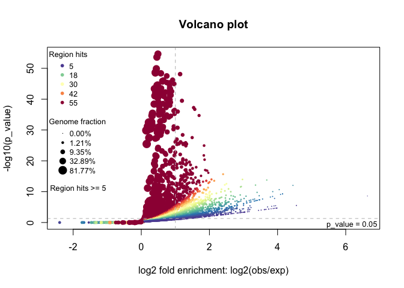

```r
plotVolcano(job, ontology = "GO Biological Process")
```

The global region-gene association plots:

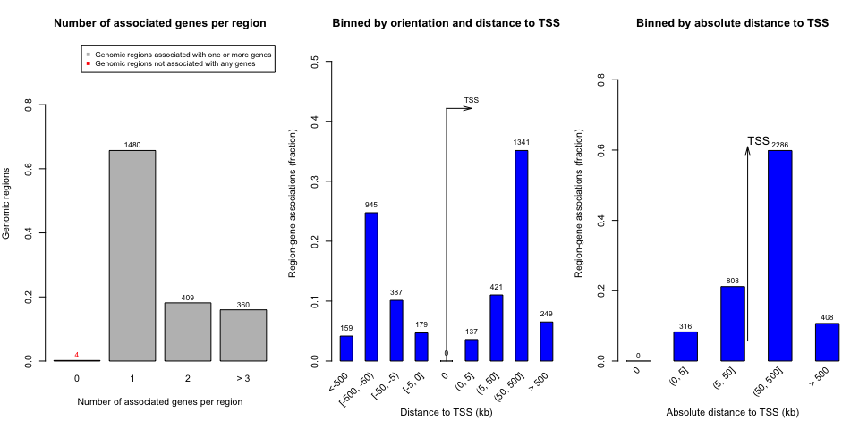

```r
plotRegionGeneAssociationGraphs(job)
```

[output not shown]

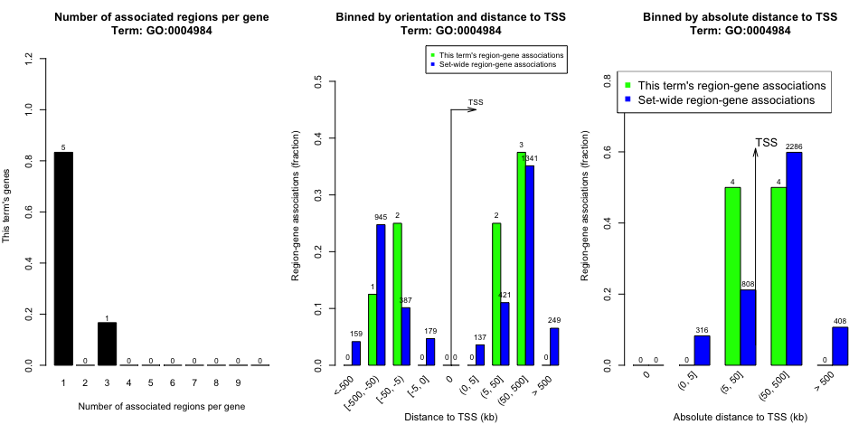

```r
plotRegionGeneAssociations(job, ontology = "GO Molecular Function",
    term_id = "GO:0004984")
```

The table of the associations between genes and regions.

```r
getRegionGeneAssociations(job, ontology = "GO Molecular Function",
    term_id = "GO:0004984")
```

```
## GRanges object with 6 ranges and 2 metadata columns:
##       seqnames              ranges strand | annotated_genes   dist_to_TSS
##          <Rle>           <IRanges>  <Rle> | <CharacterList> <IntegerList>
##   [1]     chr4   43851549-43851876      * | Olfr159,Olfr155 -67832,-12724
##   [2]     chr4   58682624-58684451      * |         Olfr267        115056
##   [3]     chr4   58690549-58691401      * |         Olfr267        107619
##   [4]     chr4   58735574-58736251      * |         Olfr267         62681
##   [5]     chr4 118315549-118316051      * |          Olfr62        -22324
##   [6]     chr7 115940724-115941576      * | Olfr514,Olfr513   28361,42778
##   -------
##   seqinfo: 2 sequences from an unspecified genome; no seqlengths
```

Try the shiny app:

```r
shinyReport(job)
```

## Perform local GREAT with `great()`

First let’s load the **rGREAT** package and generate a random set of regions:

```r
library(rGREAT)
set.seed(123)
gr = randomRegions(nr = 1000, genome = "hg19")
```

The function `great()` is the core function to perform local GREAT analysis. You can either use built-in annotations or use self-provided annotations.

### With defaultly supported annotation packages

`great()` has integrated many annotation databases which cover many organisms. Users simply specify the name of gene set collection (via the second argument) and the source of TSS (via the third argument).

```r
res = great(gr, "MSigDB:H", "txdb:hg19")
```

```
## * TSS source: TxDb.
```

```
## * extended_tss is already cached, directly use it.
```

```
## * check gene ID type in `gene_sets` and in `extended_tss`.
```

```
## * use whole genome as background.
```

```
## * remove excluded regions from background.
```

```
## * overlap `gr` to background regions (based on midpoint).
```

```
## * in total 916 `gr`.
```

```
## * overlap extended TSS to background regions.
```

```
## * check which genes are in the gene sets.
```

```
## * only take gene sets with size >= 5.
```

```
## * in total 50 gene sets.
```

```
## * overlap `gr` to every extended TSS.
```

```
## * perform binomial test for each biological term.
```

```r
res
```

```
## 916 regions are associated to 1400 genes' extended TSSs.
##   TSS source: TxDb.Hsapiens.UCSC.hg19.knownGene
##   Genome: hg19
##   OrgDb: org.Hs.eg.db
##   Gene sets: MSigDB:H
##   Background: whole genome excluding gaps
## Mode: Basal plus extension
##   Proximal: 5000 bp upstream, 1000 bp downstream,
##   plus Distal: up to 1000000 bp
```

The prefix `GO:` can be omitted when it is specified in `great()`.

The second category of gene sets are from [MSigDB](https://www.gsea-msigdb.org/gsea/msigdb/). Note this is only for human. If you want to use MSigDB for other organisms, check vignette “Work with other organisms”.

- `"msigdb:H"` Hallmark gene sets.
- `"msigdb:C1"` Positional gene sets.
- `"msigdb:C2"` Curated gene sets.
- `"msigdb:C2:CGP"` C2 subcategory: chemical and genetic perturbations gene sets.
- `"msigdb:C2:CP"` C2 subcategory: canonical pathways gene sets.
- `"msigdb:C2:CP:KEGG"` C2 subcategory: KEGG subset of CP.
- `"msigdb:C2:CP:PID"` C2 subcategory: PID subset of CP.
- `"msigdb:C2:CP:REACTOME"` C2 subcategory: REACTOME subset of CP.
- `"msigdb:C2:CP:WIKIPATHWAYS"` C2 subcategory: WIKIPATHWAYS subset of CP.
- `"msigdb:C3"` Regulatory target gene sets.
- `"msigdb:C3:MIR:MIRDB"` miRDB of microRNA targets gene sets.
- `"msigdb:C3:MIR:MIR_LEGACY"` MIR_Legacy of MIRDB.
- `"msigdb:C3:TFT:GTRD"` GTRD transcription factor targets gene sets.
- `"msigdb:C3:TFT:TFT_LEGACY"` TFT_Legacy.
- `"msigdb:C4"` Computational gene sets.
- `"msigdb:C4:CGN"` C4 subcategory: cancer gene neighborhoods gene sets.
- `"msigdb:C4:CM"` C4 subcategory: cancer modules gene sets.
- `"msigdb:C5"` Ontology gene sets.
- `"msigdb:C5:GO:BP"` C5 subcategory: BP subset.
- `"msigdb:C5:GO:CC"` C5 subcategory: CC subset.
- `"msigdb:C5:GO:MF"` C5 subcategory: MF subset.
- `"msigdb:C5:HPO"` C5 subcategory: human phenotype ontology gene sets.
- `"msigdb:C6"` Oncogenic signature gene sets.
- `"msigdb:C7"` Immunologic signature gene sets.
- `"msigdb:C7:IMMUNESIGDB"` ImmuneSigDB subset of C7.
- `"msigdb:C7:VAX"` C7 subcategory: vaccine response gene sets.
- `"msigdb:C8"` Cell type signature gene sets.

The prefix `msigdb:` can be omitted when specified in `great()` and the name of a MSigDB can be used as case insensitive.

**rGREAT** supports TSS from several sources. The value of argument `tss_source` should be encoded in a special format:

- Name of a `TxDb.*` package, e.g. `TxDb.Hsapiens.UCSC.hg19.knownGene`. Supported packages are in `rGREAT:::BIOC_ANNO_PKGS$txdb`.
- Genome version of the organism, e.g. “hg19”. Then the corresponding TxDb package will be used.
- In a format of `RefSeq:$genome` where `$genome` is the genome version of an organism. RefSeqSelect genes (directly retrieved from UCSC database) will be used.
- In a format of `RefSeqCurated:$genome` where `$genome` is the genome version of an organism. RefSeqCurated subset (directly retrieved from UCSC database) will be used.
- In a format of `RefSeqSelect:$genome` where `$genome` is the genome version of an organism. RefSeqSelect subset (directly retrieved from UCSC database) will be used.
- In a format of `Gencode_v$version` where `$version` is Gencode version, such as 19 (for human) or M21 for mouse. Gencode protein coding genes will be used.
- In a format of `GREAT:$genome`, where `$genome` can only be “mm9”, “mm10”, “hg19”, “hg38”. TSS from GREAT will be used. The data is downloaded from https://great-help.atlassian.net/wiki/spaces/GREAT/pages/655445/Genes.

The difference of `RefSeqCurated` and `RefSeqSelect` is explained in https://genome.ucsc.edu/cgi-bin/hgTrackUi?db=hg38&g=refSeqComposite.

Some examples are:

```r
great(gr, "GO:BP", "hg19")
great(gr, "GO:BP", "TxDb.Hsapiens.UCSC.hg19.knownGene")
great(gr, "GO:BP", "RefSeq:hg19")
great(gr, "GO:BP", "GREAT:hg19")
great(gr, "GO:BP", "Gencode_v19")
```

### Manually set gene sets

Here `read_gmt()` is a simple function that reads a gmt file as a list of vectors, also performs gene ID conversion.

```r
gs = read_gmt(url("http://dsigdb.tanlab.org/Downloads/D2_LINCS.gmt"),
    from = "SYMBOL", to = "ENTREZ", orgdb = "org.Hs.eg.db")
gs[1:2]
```

```
## $GSK429286A
##  [1] "5566"  "9475"  "81788" "6093"  "5562"  "26524" "5592"  "5979"  "640"
## [10] "5567"  "3717"  "5613"  "23012" "695"   "3718"
##
## $`BS-181`
##  [1] "122011" "1452"   "1022"   "7272"   "1454"   "1453"   "65975"  "147746"
##  [9] "1859"   "1195"   "1196"   "9149"   "57396"  "5261"
```

```r
great(gr, gs, "hg19")
```

```
## * TSS source: TxDb.
```

```
## * extended_tss is already cached, directly use it.
```

```
## * check gene ID type in `gene_sets` and in `extended_tss`.
```

```
## * use whole genome as background.
```

```
## * remove excluded regions from background.
```

```
## * overlap `gr` to background regions (based on midpoint).
```

```
## * in total 916 `gr`.
```

```
## * overlap extended TSS to background regions.
```

```
## * check which genes are in the gene sets.
```

```
## * only take gene sets with size >= 5.
```

```
## * in total 84 gene sets.
```

```
## * overlap `gr` to every extended TSS.
```

```
## * perform binomial test for each biological term.
```

```
## 916 regions are associated to 1400 genes' extended TSSs.
##   TSS source: TxDb.Hsapiens.UCSC.hg19.knownGene
##   Genome: hg19
##   OrgDb: org.Hs.eg.db
##   Gene sets: self-provided
##   Background: whole genome excluding gaps
## Mode: Basal plus extension
##   Proximal: 5000 bp upstream, 1000 bp downstream,
##   plus Distal: up to 1000000 bp
```

### Manually set TSS

Users may have their own set of genes/TSS, as in the following example:

```r
df = read.table(url("https://jokergoo.github.io/rGREAT_suppl/data/GREATv4.genes.hg19.tsv"))
# note there must be a 'gene_id' column
tss = GRanges(seqnames = df[, 2], ranges = IRanges(df[, 3], df[, 3]),
    strand = df[, 4], gene_id = df[, 5])
head(tss)
```

```
## GRanges object with 6 ranges and 1 metadata column:
##       seqnames    ranges strand |     gene_id
##          <Rle> <IRanges>  <Rle> | <character>
##   [1]     chr1     69090      + |       OR4F5
##   [2]     chr1    367639      + |      OR4F29
##   [3]     chr1    622053      - |      OR4F16
##   [4]     chr1    861117      + |      SAMD11
##   [5]     chr1    894670      - |       NOC2L
##   [6]     chr1    895966      + |      KLHL17
##   -------
##   seqinfo: 25 sequences from an unspecified genome; no seqlengths
```

In this case, users must manually generate an “extended TSS” by `extendTSS()` function. They should also explicitly specify the gene ID type in `extendTSS()` so that `great()` can correctly map to the genes in gene sets.

In the example, IDs for genes in `tss` are symbols, thus, `gene_id_type` must be set to `"SYMBOL"` so that the correct gene ID type will be selected for internal gene sets.

```r
et = extendTSS(tss, genome = "hg19", gene_id_type = "SYMBOL")
```

```
## * use genome 'hg19'.
```

```
## * TSS extension mode is 'basalPlusExt'.
```

```
## * construct the basal domains by extending 5000bp to upstream and 1000bp to downsteram of TSS.
```

```
## * calculate distances to neighbour regions.
```

```
## * extend to both sides until reaching the neighbour genes or to the maximal extension (1000000bp).
```

```r
great(gr, "msigdb:h", extended_tss = et)
```

```
## * check gene ID type in `gene_sets` and in `extended_tss`.
```

```
## * use whole genome as background.
```

```
## * remove excluded regions from background.
```

```
## * overlap `gr` to background regions (based on midpoint).
```

```
## * in total 916 `gr`.
```

```
## * overlap extended TSS to background regions.
```

```
## * check which genes are in the gene sets.
```

```
## * only take gene sets with size >= 5.
```

```
## * in total 50 gene sets.
```

```
## * overlap `gr` to every extended TSS.
```

```
## * perform binomial test for each biological term.
```

```
## 916 regions are associated to 1405 genes' extended TSSs.
##   TSS source: self-provided
##   Genome: hg19
##   OrgDb: org.Hs.eg.db
##   Gene sets: msigdb:h
##   Background: whole genome excluding gaps
## Mode: Basal plus extension
##   Proximal: 5000 bp upstream, 1000 bp downstream,
##   plus Distal: up to 1000000 bp
```

If gene ID type in `tss` is one of Ensembl/RefSeq/Entrez ID, `gene_id_type` argument can be omitted because the ID type can be automatically inferred from the format of the gene IDs, but it is always a good idea to explicitly specify it if the data is self-provided.

### Manually set gene sets and TSS annotations

If your organism is not defaultly supported, you can always use the `extendTSS()` to manually construct one. Note in GREAT algorithm, TSS are first extended by a rule (e.g. basal plus extension). `extendTSS()` accepts a `GRanges` object of gene or TSS and it returns a new `GRanges` object of extended TSS.

In the following example, since I don’t have data for the organism not defaultly supported by **rGREAT**. I simply use human data to demonstrate how to manually construct the extended TSS.

There are two objects for `extendTSS()`: the gene (or the TSS) and the length of chromosomes. The gene object must have a meta column named “gene_id” which stores gene ID in a specific type (this ID type will be mapped to the genes in gene sets). The chromosome length object is a named vector. It controls the set of chromosomes to be used in the analysis and the border of chromosomes when extending TSSs.

```r
library(TxDb.Hsapiens.UCSC.hg19.knownGene)
gene = genes(TxDb.Hsapiens.UCSC.hg19.knownGene)
```

```
##   403 genes were dropped because they have exons located on both strands
##   of the same reference sequence or on more than one reference sequence,
##   so cannot be represented by a single genomic range.
##   Use 'single.strand.genes.only=FALSE' to get all the genes in a
##   GRangesList object, or use suppressMessages() to suppress this message.
```

```r
gene = gene[seqnames(gene) %in% paste0("chr", c(1:22, "X", "Y"))]
head(gene)
```

```
## GRanges object with 6 ranges and 1 metadata column:
##             seqnames              ranges strand |     gene_id
##                <Rle>           <IRanges>  <Rle> | <character>
##           1    chr19   58858172-58874214      - |           1
##          10     chr8   18248755-18258723      + |          10
##         100    chr20   43248163-43280376      - |         100
##        1000    chr18   25530930-25757445      - |        1000
##       10000     chr1 243651535-244006886      - |       10000
##   100008586     chrX   49217763-49233491      + |   100008586
##   -------
##   seqinfo: 93 sequences (1 circular) from hg19 genome
```

```r
gl = seqlengths(gene)[paste0("chr", c(1:22, "X", "Y"))]  # restrict to normal chromosomes
head(gl)
```

```
##      chr1      chr2      chr3      chr4      chr5      chr6
## 249250621 243199373 198022430 191154276 180915260 171115067
```

Simply send `gene` and `gl` to `extendTSS()`:

```r
et = extendTSS(gene, gl)
```

```
## * TSS extension mode is 'basalPlusExt'.
```

```
## * construct the basal domains by extending 5000bp to upstream and 1000bp to downsteram of TSS.
```

```
## * calculate distances to neighbour regions.
```

```
## * extend to both sides until reaching the neighbour genes or to the maximal extension (1000000bp).
```

```r
head(et)
```

```
## GRanges object with 6 ranges and 3 metadata columns:
##             seqnames        ranges strand |     gene_id tss_position
##                <Rle>     <IRanges>  <Rle> | <character>    <integer>
##   100287102     chr1       1-28962      * |   100287102        11874
##      653635     chr1   12873-64091      * |      653635        29961
##       79501     chr1  34961-139567      * |       79501        69091
##      729737     chr1  70090-713069      * |      729737       140566
##   100288069     chr1 145566-757971      * |   100288069       714068
##      643837     chr1 719068-763970      * |      643837       762971
##              tss_strand
##             <character>
##   100287102           +
##      653635           -
##       79501           +
##      729737           -
##   100288069           -
##      643837           +
##   -------
##   seqinfo: 24 sequences from an unspecified genome
```

We can also manually construct the gene sets object, which is simply a named list of vectors where each vector contains genes in a gene set. Here we directly use the object `gs` generated before which is a gene set collection from DSigDB.

Please note again, gene IDs in `gs` (the gene sets) should be the same as in `et` (the extended TSSs).

Now `gs` and `et` can be sent to `great()` to perform local GREAT with the annotation data you manually provided.

```r
great(gr, gene_sets = gs, extended_tss = et)
```

```
## * check gene ID type in `gene_sets` and in `extended_tss`.
```

```
## * use whole genome as background.
```

```
## * remove excluded regions from background.
```

```
## * overlap `gr` to background regions (based on midpoint).
```

```
## * in total 1000 `gr`.
```

```
## * overlap extended TSS to background regions.
```

```
## * check which genes are in the gene sets.
```

```
## * only take gene sets with size >= 5.
```

```
## * in total 84 gene sets.
```

```
## * overlap `gr` to every extended TSS.
```

```
## * perform binomial test for each biological term.
```

[output not shown]

```
## 1000 regions are associated to 1490 genes' extended TSSs.
##   TSS source: self-provided
##   Genome: unknown
##   Gene sets: self-provided
##   Background: whole genome
## Mode: Basal plus extension
##   Proximal: 5000 bp upstream, 1000 bp downstream,
##   plus Distal: up to 1000000 bp
```

## Use BioMart genes and genesets

**rGREAT** also supports GO gene sets for a huge number of organisms retrieved from [Ensembl BioMart](https://www.ensembl.org/info/data/biomart/index.html). A specific organism can be set with the `biomart_dataset` argument:

```r
# Giant panda
gr_panda = randomRegionsFromBioMartGenome("amelanoleuca_gene_ensembl")
great(gr_panda, "GO:BP", biomart_dataset = "amelanoleuca_gene_ensembl")
```

```
## * get gene and GO genesets from biomart (dataset: amelanoleuca_gene_ensembl).
```

```
## * background chromosomes from BioMart are '9, 3, 13, 2, 8, 4, 6, 14, 7, 15, 5, X, 1, 10,
##     12, 11, 18, 17, 16'.
```

```
## * TSS extension mode is 'basalPlusExt'.
```

```
## * construct the basal domains by extending 5000bp to upstream and 1000bp to downsteram of TSS.
```

```
## * calculate distances to neighbour regions.
```

```
## * extend to both sides until reaching the neighbour genes or to the maximal extension (1000000bp).
```

```
## * check gene ID type in `gene_sets` and in `extended_tss`.
```

```
## * use whole genome as background.
```

```
## * overlap `gr` to background regions (based on midpoint).
```

```
## * in total 960 `gr`.
```

```
## * overlap extended TSS to background regions.
```

```
## * check which genes are in the gene sets.
```

```
## * only take gene sets with size >= 5.
```

```
## * in total 7521 gene sets.
```

```
## * overlap `gr` to every extended TSS.
```

```
## * perform binomial test for each biological term.
```

[output not shown]

[output cut: 113 more lines]

[output not shown]

```
## 960 regions are associated to 1578 genes' extended TSSs.
##   TSS source: amelanoleuca_gene_ensembl
##   Genome: Giant panda genes (ASM200744v2)
##   Gene sets: GO:BP
##   Background: whole genome
## Mode: Basal plus extension
##   Proximal: 5000 bp upstream, 1000 bp downstream,
##   plus Distal: up to 1000000 bp
```

Note both TSS and gene sets are from BioMart. The value for gene sets (the second argument) can only be one of `"GO:BP"`, `"GO:CC"` and `"GO:MF"`.

**rGREAT** now supports more than 600 organisms. The complete list can be found with `BioMartGOGeneSets::supportedOrganisms()`.

For non-model organisms, the default chromosomes may include many small contigs. You can set the `background` argument to a vector of chromosomes that you want to include.

## Set background regions

In the online GREAT tool, if background regions are set, [it actually uses a different test for the enrichment analysis](https://great-help.atlassian.net/wiki/spaces/GREAT/pages/655456/Statistics#Statistics-ExplicitBackgroundSet). In GREAT, when background is set, input regions should be **exactly subset of background**. For example, let’s say a background region list contains five regions: `[1, 10], [15, 23], [34, 38], [40, 49], [54, 63]`, input regions can only be a subset of the five regions, which means they can take `[15, 23], [40, 49]`, but it cannot take `[16, 20], [39, 51]`. In this setting, regions are taken as single units and Fisher’s exact test is applied for calculating the enrichment (by testing number of regions in the 2x2 contigency table).

This might be useful for certain cases, e.g., for a specific transcriptional factor (TF), we take the union of ChIP-seq peaks of this TF from all tissues as the background set, and only take peaks from one specific tisse as input region set, and we want to test the enrichment of TF peaks in the tissue compared to the “background”. However, this “background definition” might not be the case as many other users may think. They might take “background” as a set of regions where they only want to perform GREAT (the Binomial method) in. E.g. they may want to exclude “gap regions / unsequenced regions” from the analysis because the null hypothesis of Binomial test is the input regions are uniformly distributed in the genome. Since the unsequenced regions will never be measured, they should be excluded from the analysis. Other examples are that the background can be set as regions showing similar GC contents or CpG density as the input regions.

`great()` supports two arguments `background` and `exclude` for setting a proper background. If any one of the two is set, the input regions and the extended TSS regions are intersected to the background, and GREAT algorithm is only applied to the reduced regions.

When whole genome is set as background, denote $N_1$ as the total number of input regions, $p_1$ as the fraction of genome that are overlapped to extended TSS of genes in a certain gene set, and $K_1$ as the number of regions that overlap to the gene set associated regions, then the enrichment test is based on the random variable $K_1$ which follows Binomial distribution $K_1 \sim B(p_1, N_1)$.

Similarly, when background regions are set, denote $N_2$ as the total number of input regions that overlap to backgroud, $p_2$ as the fraction of background that are overlapped to extended TSS of genes in a certain gene set, and $K_2$ as the number of regions that overlap to the gene set associated regions and also overlap to background, then the enrichment test is based on the random variable $K_2$ which follows Binomial distribution $K_2 \sim B(p_2, N_2)$.

In fact, the native hypergeometric method in GREAT can be approximated to the binomial method here. Nevertheless, the binomial method is more general and it has no restriction as the hypergeometric method where input regions must be perfect subsets of backgrounds.

In the following example, `getGapFromUCSC()` can be used to retrieve gap regions from UCSC table browser.

```r
gap = getGapFromUCSC("hg19", paste0("chr", c(1:22, "X", "Y")))
great(gr, "MSigDB:H", "hg19", exclude = gap)
```

**Note as the same as online GREAT, rGREAT by default excludes gap regions from the analysis.**

Alternatively, `background` and `exclude` can also be set to a vector of chromosome names, then the whole selected chromosomes will be included/excluded from the analysis.

```r
great(gr, "GO:BP", background = paste0("chr", 1:22))
great(gr, "GO:BP", exclude = c("chrX", "chrY"))
```

## Get enrichment table

Simply use `getEnrichmentTable()` function.

```r
tb = getEnrichmentTable(res)
head(tb)
```

```
##                                   id genome_fraction observed_region_hits
## 1                 HALLMARK_APOPTOSIS     0.015572219                   22
## 2           HALLMARK_SPERMATOGENESIS     0.013943482                   20
## 3       HALLMARK_IL2_STAT5_SIGNALING     0.021152759                   25
## 4      HALLMARK_BILE_ACID_METABOLISM     0.010077105                   13
## 5        HALLMARK_HEDGEHOG_SIGNALING     0.006965189                    9
## 6 HALLMARK_OXIDATIVE_PHOSPHORYLATION     0.012476423                   14
##   fold_enrichment    p_value  p_adjust mean_tss_dist observed_gene_hits
## 1        1.542328 0.03308353 0.7148313        250612                 18
## 2        1.565897 0.03574156 0.7148313        233929                 18
## 3        1.290261 0.12179347 0.8728821        189866                 22
## 4        1.408355 0.14054771 0.8728821        167309                 12
## 5        1.410633 0.19372944 0.8728821        307394                  7
## 6        1.225018 0.25884518 0.8728821        148492                 13
##   gene_set_size fold_enrichment_hyper p_value_hyper p_adjust_hyper
## 1           158             1.5105515    0.05180621      0.3453747
## 2           134             1.7810981    0.01192743      0.2197825
## 3           196             1.4882872    0.03956849      0.3320113
## 4           112             1.4206378    0.13766929      0.5506772
## 5            36             2.5781944    0.01648369      0.2197825
## 6           199             0.8661845    0.74420267      0.9737239
```

In `getEnrichmentTable()`, you can set argument `min_region_hits` to set the minimal number of input regions that hit a geneset-associated regions. Note the adjusted p-values will be recalculated in the table.

There are also columns for hypergeometric test on the numbers of genes, the same as in the original GREAT method.

There is a new column “mean_tss_dist” in the result table which is the mean absolute distance of input regions to TSS of genes in a gene set. Please note with larger distance to TSS, the more we need to be careful with the reliability of the associations between input regions to genes.

## Make volcano plot

In differential gene expression analysis, volcano plot is used to visualize relations between log2 fold change and (adjusted) p-values. Similarly, we can also use volcano plot to visualize relations between fold enrichment and (adjusted) p-values for the enrichment analysis. The plot is made by the function `plotVolcano()`:

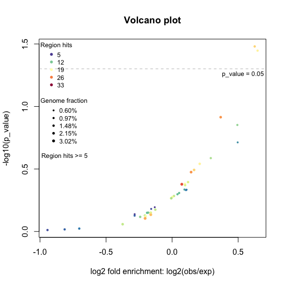

```r
plotVolcano(res)
```

As the enrichment analysis basically only looks for over-representations, it is actually half volcano.

## Get region-gene associations

`plotRegionGeneAssociations()` generates three plots similar as those by online GREAT. `getRegionGeneAssociations()` returns a `GRanges` object containing associations between regions and genes.

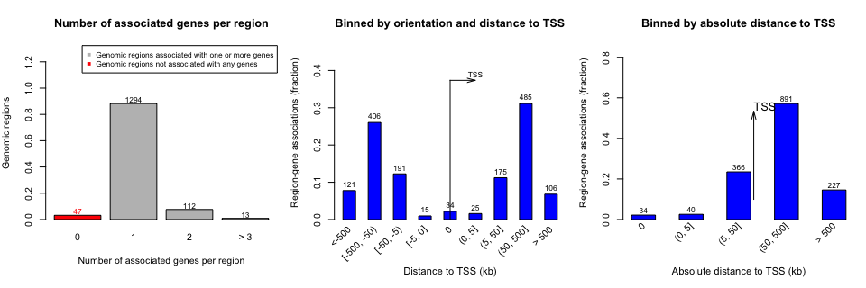

```r
plotRegionGeneAssociations(res)
```

```r
getRegionGeneAssociations(res)
```

```
## GRanges object with 869 ranges and 2 metadata columns:
##         seqnames            ranges strand | annotated_genes    dist_to_TSS
##            <Rle>         <IRanges>  <Rle> | <CharacterList>  <IntegerList>
##     [1]     chr1   9204434-9208784      * |     GPR157,H6PD  -15205,-86079
##     [2]     chr1   9853594-9859363      * |   PIK3CD,CLSTN1   141804,25187
##     [3]     chr1 10862809-10871681      * |  CASZ1,C1orf127   -6076,170413
##     [4]     chr1 12716970-12723206      * | AADACL4,AADACL3   12404,-52912
##     [5]     chr1 13814692-13823250      * | PRAMEF17,LRRC38    98604,16992
##     ...      ...               ...    ... .             ...            ...
##   [865]     chrY 16384799-16389852      * |   TMSB4Y,NLGN4Y 569352,-244636
##   [866]     chrY 16842593-16846893      * |          NLGN4Y         208105
##   [867]     chrY 16998750-17003225      * |          NLGN4Y         364262
##   [868]     chrY 24401612-24406252      * |   RBMY1E,RBMY1F  -72523,-48754
##   [869]     chrY 26206997-26215445      * |            DAZ2         841416
##   -------
##   seqinfo: 26 sequences from an unspecified genome; no seqlengths
```

Being different from the online GREAT, `getRegionGeneAssociations()` on the local GREAT object calculates the distance to TSS based on the borders of the input regions. The argument `by_middle_points` can be set to `TRUE` to let the distance be based on the middle points of input regions.

Please note the two meta columns are in formats of `CharacterList` and `IntegerList` because a region may associate to multiple genes.

Of course you can set a specific geneset term by argument `term_id`.

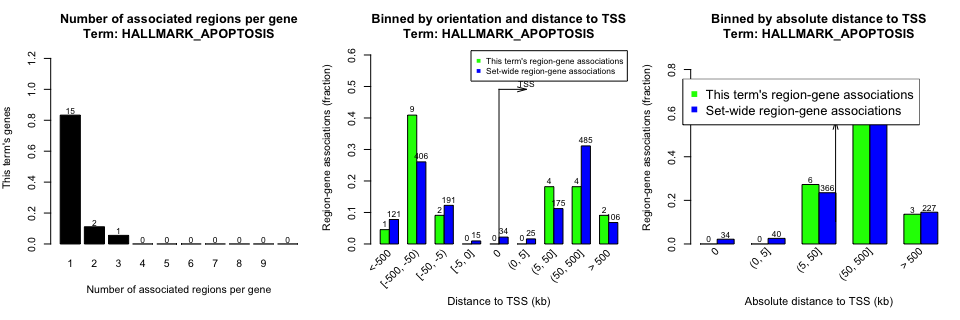

```r
plotRegionGeneAssociations(res, term_id = "HALLMARK_APOPTOSIS")
```

```r
getRegionGeneAssociations(res, term_id = "HALLMARK_APOPTOSIS")
```

```
## GRanges object with 22 ranges and 2 metadata columns:
##        seqnames            ranges strand | annotated_genes   dist_to_TSS
##           <Rle>         <IRanges>  <Rle> | <CharacterList> <IntegerList>
##    [1]     chr1 40515463-40519356      * |            PPT1         43786
##    [2]     chr1 97386537-97391160      * |            DPYD        995455
##    [3]     chr1 98324960-98333882      * |            DPYD         52733
##    [4]     chr1 98723726-98728003      * |            DPYD       -337111
##    [5]     chr3 18185589-18193193      * |           SATB1        287072
##    ...      ...               ...    ... .             ...           ...
##   [18]    chr19   2644522-2653683      * |         GADD45B        168399
##   [19]    chr20   6656761-6662137      * |            BMP2        -86608
##   [20]    chr20   7709225-7716863      * |            BMP2        960480
##   [21]    chr21 27698626-27707770      * |             APP       -155180
##   [22]    chr22 21271471-21278063      * |           AIFM3        -41355
##   -------
##   seqinfo: 26 sequences from an unspecified genome; no seqlengths
```

## The Shiny application

`shinyReport()` creates a Shiny application to view the complete results:

```r
shinyReport(res)
```